# Optimal Treatment Analysis

## Outcome Variable

**Outcome Variable:** whz

## Predictor Variables

**Intervention Variable:** mwtkg

**Adjustment Set:**

- arm
- W_mage
- meducyrs
- feducyrs
- single
- brthmon
- W_parity
- delta_W_mage
- delta_meducyrs
- delta_feducyrs
- delta_single
- delta_brthmon
- delta_W_parity

## Stratifying Variables

The analysis was stratified on these variable(s):

- agecat
- studyid
- country

## Data Summary

| agecat | studyid | country | mwtkg | n_cell | n |
| --- | --- | --- | --- | --- | --- |
| Birth | JiVitA-3 | BANGLADESH | >=58 kg | 427 | 17995 |
| Birth | JiVitA-3 | BANGLADESH | <52 kg | 16351 | 17995 |
| Birth | JiVitA-3 | BANGLADESH | [52-58) kg | 1217 | 17995 |
| Birth | MAL-ED | BANGLADESH | >=58 kg | 37 | 209 |
| Birth | MAL-ED | BANGLADESH | <52 kg | 131 | 209 |
| Birth | MAL-ED | BANGLADESH | [52-58) kg | 41 | 209 |
| Birth | MAL-ED | BRAZIL | >=58 kg | 33 | 61 |
| Birth | MAL-ED | BRAZIL | <52 kg | 14 | 61 |
| Birth | MAL-ED | BRAZIL | [52-58) kg | 14 | 61 |
| Birth | MAL-ED | INDIA | >=58 kg | 6 | 41 |
| Birth | MAL-ED | INDIA | <52 kg | 28 | 41 |
| Birth | MAL-ED | INDIA | [52-58) kg | 7 | 41 |
| Birth | MAL-ED | NEPAL | >=58 kg | 9 | 26 |
| Birth | MAL-ED | NEPAL | <52 kg | 7 | 26 |
| Birth | MAL-ED | NEPAL | [52-58) kg | 10 | 26 |
| Birth | MAL-ED | PERU | >=58 kg | 82 | 221 |
| Birth | MAL-ED | PERU | <52 kg | 81 | 221 |
| Birth | MAL-ED | PERU | [52-58) kg | 58 | 221 |
| Birth | MAL-ED | SOUTH AFRICA | >=58 kg | 69 | 100 |
| Birth | MAL-ED | SOUTH AFRICA | <52 kg | 10 | 100 |
| Birth | MAL-ED | SOUTH AFRICA | [52-58) kg | 21 | 100 |
| Birth | MAL-ED | TANZANIA, UNITED REPUBLIC OF | >=58 kg | 44 | 113 |
| Birth | MAL-ED | TANZANIA, UNITED REPUBLIC OF | <52 kg | 40 | 113 |
| Birth | MAL-ED | TANZANIA, UNITED REPUBLIC OF | [52-58) kg | 29 | 113 |
| Birth | NIH-Birth | BANGLADESH | >=58 kg | 79 | 575 |
| Birth | NIH-Birth | BANGLADESH | <52 kg | 414 | 575 |
| Birth | NIH-Birth | BANGLADESH | [52-58) kg | 82 | 575 |
| Birth | NIH-Crypto | BANGLADESH | >=58 kg | 183 | 704 |
| Birth | NIH-Crypto | BANGLADESH | <52 kg | 381 | 704 |
| Birth | NIH-Crypto | BANGLADESH | [52-58) kg | 140 | 704 |

[output cut: 105 more lines]

The following strata were considered:

- agecat: 24 months, studyid: JiVitA-3, country: BANGLADESH
- agecat: 24 months, studyid: LCNI-5, country: MALAWI
- agecat: 24 months, studyid: MAL-ED, country: BANGLADESH
- agecat: 24 months, studyid: MAL-ED, country: BRAZIL
- agecat: 24 months, studyid: MAL-ED, country: INDIA
- agecat: 24 months, studyid: MAL-ED, country: NEPAL
- agecat: 24 months, studyid: MAL-ED, country: PERU
- agecat: 24 months, studyid: MAL-ED, country: SOUTH AFRICA
- agecat: 24 months, studyid: MAL-ED, country: TANZANIA, UNITED REPUBLIC OF
- agecat: 24 months, studyid: NIH-Birth, country: BANGLADESH
- agecat: 24 months, studyid: NIH-Crypto, country: BANGLADESH
- agecat: 24 months, studyid: PROBIT, country: BELARUS
- agecat: 24 months, studyid: PROVIDE, country: BANGLADESH
- agecat: 24 months, studyid: TanzaniaChild2, country: TANZANIA, UNITED REPUBLIC OF
- agecat: 24 months, studyid: ZVITAMBO, country: ZIMBABWE
- agecat: 6 months, studyid: JiVitA-3, country: BANGLADESH
- agecat: 6 months, studyid: LCNI-5, country: MALAWI
- agecat: 6 months, studyid: MAL-ED, country: BANGLADESH
- agecat: 6 months, studyid: MAL-ED, country: BRAZIL
- agecat: 6 months, studyid: MAL-ED, country: INDIA
- agecat: 6 months, studyid: MAL-ED, country: NEPAL
- agecat: 6 months, studyid: MAL-ED, country: PERU
- agecat: 6 months, studyid: MAL-ED, country: SOUTH AFRICA
- agecat: 6 months, studyid: MAL-ED, country: TANZANIA, UNITED REPUBLIC OF
- agecat: 6 months, studyid: NIH-Birth, country: BANGLADESH
- agecat: 6 months, studyid: NIH-Crypto, country: BANGLADESH
- agecat: 6 months, studyid: PROBIT, country: BELARUS
- agecat: 6 months, studyid: PROVIDE, country: BANGLADESH
- agecat: 6 months, studyid: SAS-CompFeed, country: INDIA
- agecat: 6 months, studyid: TanzaniaChild2, country: TANZANIA, UNITED REPUBLIC OF
- agecat: 6 months, studyid: ZVITAMBO, country: ZIMBABWE
- agecat: Birth, studyid: JiVitA-3, country: BANGLADESH
- agecat: Birth, studyid: MAL-ED, country: BANGLADESH
- agecat: Birth, studyid: MAL-ED, country: BRAZIL
- agecat: Birth, studyid: MAL-ED, country: INDIA
- agecat: Birth, studyid: MAL-ED, country: NEPAL
- agecat: Birth, studyid: MAL-ED, country: PERU
- agecat: Birth, studyid: MAL-ED, country: SOUTH AFRICA
- agecat: Birth, studyid: MAL-ED, country: TANZANIA, UNITED REPUBLIC OF
- agecat: Birth, studyid: NIH-Birth, country: BANGLADESH
- agecat: Birth, studyid: NIH-Crypto, country: BANGLADESH
- agecat: Birth, studyid: PROBIT, country: BELARUS
- agecat: Birth, studyid: PROVIDE, country: BANGLADESH
- agecat: Birth, studyid: SAS-CompFeed, country: INDIA
- agecat: Birth, studyid: ZVITAMBO, country: ZIMBABWE

### Dropped Strata

Some strata were dropped due to rare outcomes:

- agecat: 24 months, studyid: TanzaniaChild2, country: TANZANIA, UNITED REPUBLIC OF

## Methods Detail

We’re interested in the causal parameters $E[Y_a]$ for all values of $a \in \mathcal{A}$. These parameters represent the mean outcome if, possibly contrary to fact, we intervened to set all units to have $A=a$. Under the randomization and positivity assumptions, these are identified by the statistical parameters $\psi_a=E_W[E_{Y|A,W}(Y|A=a,W)]$. In addition, we’re interested in the mean of $Y$, $E[Y]$ under no intervention (the observed mean). We will estimate these parameters by using SuperLearner to fit the relevant likelihood factors – $E_{Y|A,W}(Y|A=a,W)$ and $p(A=a|W)$, and then updating our likelihood fit using a joint TMLE.

For unadjusted analyses ($W=\{\}$), initial likelihoods were estimated using Lrnr_glm to estimate the simple $E(Y|A)$ and Lrnr_mean to estimate $p(A)$. For adjusted analyses, a small library containing Lrnr_glmnet, Lrnr_xgboost, and Lrnr_mean was used.

Having estimated these parameters, we will then use the delta method to estimate relative risks and attributable risks relative to a prespecified baseline level of $A$.

# Results Detail

## Results Plots

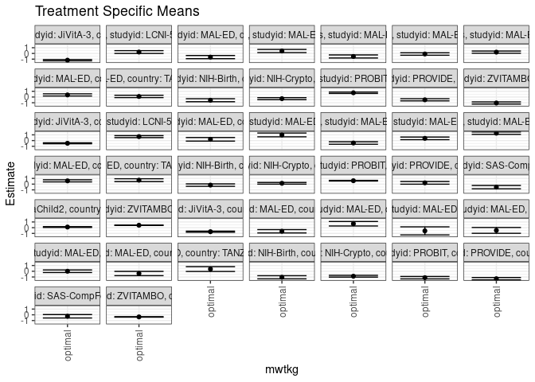

## Results Table

### Parameter: TSM

| agecat | studyid | country | intervention_level | baseline_level | estimate | ci_lower | ci_upper |
| --- | --- | --- | --- | --- | --- | --- | --- |
| Birth | JiVitA-3 | BANGLADESH | optimal | observed | -0.6988856 | -0.7955163 | -0.6022549 |
| Birth | MAL-ED | BANGLADESH | optimal | observed | -0.6258649 | -0.9165611 | -0.3351688 |
| Birth | MAL-ED | BRAZIL | optimal | observed | 0.6887350 | 0.2932865 | 1.0841834 |
| Birth | MAL-ED | INDIA | optimal | observed | -0.5569875 | -1.2615727 | 0.1475978 |
| Birth | MAL-ED | NEPAL | optimal | observed | -0.4722980 | -0.9814515 | 0.0368555 |
| Birth | MAL-ED | PERU | optimal | observed | 0.0012025 | -0.2255205 | 0.2279254 |
| Birth | MAL-ED | SOUTH AFRICA | optimal | observed | -0.3950283 | -0.7678254 | -0.0222313 |
| Birth | MAL-ED | TANZANIA, UNITED REPUBLIC OF | optimal | observed | 0.3828280 | -0.0357291 | 0.8013851 |
| Birth | NIH-Birth | BANGLADESH | optimal | observed | -1.0495742 | -1.3237004 | -0.7754480 |
| Birth | NIH-Crypto | BANGLADESH | optimal | observed | -0.8675490 | -1.0245957 | -0.7105024 |
| Birth | PROBIT | BELARUS | optimal | observed | -1.1239755 | -1.3358188 | -0.9121323 |
| Birth | PROVIDE | BANGLADESH | optimal | observed | -1.3003733 | -1.5024984 | -1.0982483 |
| Birth | SAS-CompFeed | INDIA | optimal | observed | -0.2574734 | -0.5550827 | 0.0401359 |
| Birth | ZVITAMBO | ZIMBABWE | optimal | observed | -0.3665275 | -0.4069449 | -0.3261101 |
| 6 months | JiVitA-3 | BANGLADESH | optimal | observed | -0.4733556 | -0.5583290 | -0.3883821 |
| 6 months | LCNI-5 | MALAWI | optimal | observed | 0.6886699 | 0.5129382 | 0.8644016 |
| 6 months | MAL-ED | BANGLADESH | optimal | observed | 0.2176359 | -0.0944555 | 0.5297272 |
| 6 months | MAL-ED | BRAZIL | optimal | observed | 0.9830756 | 0.6541816 | 1.3119695 |
| 6 months | MAL-ED | INDIA | optimal | observed | -0.4259984 | -0.6417208 | -0.2102759 |
| 6 months | MAL-ED | NEPAL | optimal | observed | 0.3858386 | 0.1574445 | 0.6142328 |
| 6 months | MAL-ED | PERU | optimal | observed | 1.2874701 | 1.0799920 | 1.4949482 |
| 6 months | MAL-ED | SOUTH AFRICA | optimal | observed | 0.5740608 | 0.3874152 | 0.7607064 |
| 6 months | MAL-ED | TANZANIA, UNITED REPUBLIC OF | optimal | observed | 0.6875733 | 0.4387376 | 0.9364091 |
| 6 months | NIH-Birth | BANGLADESH | optimal | observed | -0.1709624 | -0.3811906 | 0.0392658 |
| 6 months | NIH-Crypto | BANGLADESH | optimal | observed | 0.1447502 | -0.0038206 | 0.2933210 |
| 6 months | PROBIT | BELARUS | optimal | observed | 0.5944523 | 0.5354932 | 0.6534114 |
| 6 months | PROVIDE | BANGLADESH | optimal | observed | 0.2217433 | -0.0133344 | 0.4568209 |
| 6 months | SAS-CompFeed | INDIA | optimal | observed | -0.5266421 | -0.8164815 | -0.2368027 |
| 6 months | TanzaniaChild2 | TANZANIA, UNITED REPUBLIC OF | optimal | observed | 0.1131183 | 0.0431409 | 0.1830956 |
| 6 months | ZVITAMBO | ZIMBABWE | optimal | observed | 0.4243773 | 0.3885131 | 0.4602416 |
| 24 months | JiVitA-3 | BANGLADESH | optimal | observed | -1.1747216 | -1.2841618 | -1.0652815 |
| 24 months | LCNI-5 | MALAWI | optimal | observed | 0.2426236 | -0.0043870 | 0.4896342 |
| 24 months | MAL-ED | BANGLADESH | optimal | observed | -0.6377649 | -0.9150807 | -0.3604491 |
| 24 months | MAL-ED | BRAZIL | optimal | observed | 0.4240958 | 0.1451062 | 0.7030855 |
| 24 months | MAL-ED | INDIA | optimal | observed | -0.5269028 | -0.7950602 | -0.2587453 |
| 24 months | MAL-ED | NEPAL | optimal | observed | -0.0969337 | -0.3114331 | 0.1175657 |
| 24 months | MAL-ED | PERU | optimal | observed | 0.2266623 | 0.0338518 | 0.4194728 |
| 24 months | MAL-ED | SOUTH AFRICA | optimal | observed | 0.3643568 | 0.1730548 | 0.5556588 |
| 24 months | MAL-ED | TANZANIA, UNITED REPUBLIC OF | optimal | observed | 0.0986003 | -0.1070479 | 0.3042485 |
| 24 months | NIH-Birth | BANGLADESH | optimal | observed | -0.5618219 | -0.8225281 | -0.3011157 |
| 24 months | NIH-Crypto | BANGLADESH | optimal | observed | -0.2898656 | -0.4686193 | -0.1111120 |
| 24 months | PROBIT | BELARUS | optimal | observed | 0.7379866 | 0.6150581 | 0.8609152 |
| 24 months | PROVIDE | BANGLADESH | optimal | observed | -0.4876824 | -0.6767410 | -0.2986238 |
| 24 months | ZVITAMBO | ZIMBABWE | optimal | observed | -1.0443520 | -1.2286547 | -0.8600493 |

### Parameter: E(Y)

| agecat | studyid | country | intervention_level | baseline_level | estimate | ci_lower | ci_upper |
| --- | --- | --- | --- | --- | --- | --- | --- |
| Birth | JiVitA-3 | BANGLADESH | observed | observed | -0.7780622 | -0.7970926 | -0.7590319 |
| Birth | MAL-ED | BANGLADESH | observed | observed | -0.9533493 | -1.0984355 | -0.8082631 |
| Birth | MAL-ED | BRAZIL | observed | observed | 0.4018033 | 0.0834093 | 0.7201973 |
| Birth | MAL-ED | INDIA | observed | observed | -0.9678049 | -1.2522118 | -0.6833979 |
| Birth | MAL-ED | NEPAL | observed | observed | -0.7684615 | -1.1257770 | -0.4111460 |
| Birth | MAL-ED | PERU | observed | observed | -0.0429864 | -0.1658406 | 0.0798678 |
| Birth | MAL-ED | SOUTH AFRICA | observed | observed | -0.1930000 | -0.4278634 | 0.0418634 |
| Birth | MAL-ED | TANZANIA, UNITED REPUBLIC OF | observed | observed | 0.7583186 | 0.5636385 | 0.9529987 |
| Birth | NIH-Birth | BANGLADESH | observed | observed | -1.3499217 | -1.4444634 | -1.2553801 |
| Birth | NIH-Crypto | BANGLADESH | observed | observed | -1.2434730 | -1.3276901 | -1.1592559 |
| Birth | PROBIT | BELARUS | observed | observed | -1.1473357 | -1.3582781 | -0.9363933 |
| Birth | PROVIDE | BANGLADESH | observed | observed | -1.3060980 | -1.3843247 | -1.2278714 |
| Birth | SAS-CompFeed | INDIA | observed | observed | -0.6660770 | -0.8389738 | -0.4931801 |
| Birth | ZVITAMBO | ZIMBABWE | observed | observed | -0.4824198 | -0.5113303 | -0.4535093 |
| 6 months | JiVitA-3 | BANGLADESH | observed | observed | -0.5934435 | -0.6129939 | -0.5738931 |
| 6 months | LCNI-5 | MALAWI | observed | observed | 0.4518519 | 0.3806435 | 0.5230602 |
| 6 months | MAL-ED | BANGLADESH | observed | observed | -0.1376763 | -0.2664642 | -0.0088885 |
| 6 months | MAL-ED | BRAZIL | observed | observed | 0.9648518 | 0.8004118 | 1.1292917 |
| 6 months | MAL-ED | INDIA | observed | observed | -0.7034149 | -0.8300527 | -0.5767771 |
| 6 months | MAL-ED | NEPAL | observed | observed | 0.1104308 | -0.0208643 | 0.2417259 |
| 6 months | MAL-ED | PERU | observed | observed | 1.0548591 | 0.9328922 | 1.1768259 |
| 6 months | MAL-ED | SOUTH AFRICA | observed | observed | 0.5291499 | 0.3751396 | 0.6831602 |
| 6 months | MAL-ED | TANZANIA, UNITED REPUBLIC OF | observed | observed | 0.5362213 | 0.4049390 | 0.6675036 |
| 6 months | NIH-Birth | BANGLADESH | observed | observed | -0.4474038 | -0.5378167 | -0.3569909 |
| 6 months | NIH-Crypto | BANGLADESH | observed | observed | 0.0297622 | -0.0491685 | 0.1086930 |
| 6 months | PROBIT | BELARUS | observed | observed | 0.5788311 | 0.5205227 | 0.6371396 |
| 6 months | PROVIDE | BANGLADESH | observed | observed | -0.1987071 | -0.2815473 | -0.1158669 |
| 6 months | SAS-CompFeed | INDIA | observed | observed | -0.6660835 | -0.8034722 | -0.5286949 |
| 6 months | TanzaniaChild2 | TANZANIA, UNITED REPUBLIC OF | observed | observed | 0.0780261 | 0.0247830 | 0.1312691 |
| 6 months | ZVITAMBO | ZIMBABWE | observed | observed | 0.2987004 | 0.2725093 | 0.3248915 |
| 24 months | JiVitA-3 | BANGLADESH | observed | observed | -1.2974564 | -1.3207535 | -1.2741592 |
| 24 months | LCNI-5 | MALAWI | observed | observed | -0.0466281 | -0.1286250 | 0.0353688 |
| 24 months | MAL-ED | BANGLADESH | observed | observed | -0.8192925 | -0.9412667 | -0.6973182 |
| 24 months | MAL-ED | BRAZIL | observed | observed | 0.4443651 | 0.2404149 | 0.6483153 |
| 24 months | MAL-ED | INDIA | observed | observed | -0.9519248 | -1.0678488 | -0.8360007 |
| 24 months | MAL-ED | NEPAL | observed | observed | -0.3749123 | -0.4886073 | -0.2612173 |
| 24 months | MAL-ED | PERU | observed | observed | 0.1111982 | -0.0118399 | 0.2342362 |
| 24 months | MAL-ED | SOUTH AFRICA | observed | observed | 0.3916417 | 0.2704414 | 0.5128421 |
| 24 months | MAL-ED | TANZANIA, UNITED REPUBLIC OF | observed | observed | 0.0547975 | -0.0703378 | 0.1799328 |
| 24 months | NIH-Birth | BANGLADESH | observed | observed | -0.9115790 | -1.0095022 | -0.8136559 |
| 24 months | NIH-Crypto | BANGLADESH | observed | observed | -0.6103502 | -0.7050157 | -0.5156847 |
| 24 months | PROBIT | BELARUS | observed | observed | 0.6995588 | 0.5828687 | 0.8162490 |
| 24 months | PROVIDE | BANGLADESH | observed | observed | -0.8914360 | -0.9741797 | -0.8086923 |
| 24 months | ZVITAMBO | ZIMBABWE | observed | observed | -1.1835154 | -1.2835950 | -1.0834359 |

### Parameter: PAR

| agecat | studyid | country | intervention_level | baseline_level | estimate | ci_lower | ci_upper |
| --- | --- | --- | --- | --- | --- | --- | --- |
| Birth | JiVitA-3 | BANGLADESH | optimal | observed | -0.0791766 | -0.1734178 | 0.0150645 |
| Birth | MAL-ED | BANGLADESH | optimal | observed | -0.3274843 | -0.6057747 | -0.0491939 |
| Birth | MAL-ED | BRAZIL | optimal | observed | -0.2869317 | -0.5935803 | 0.0197169 |
| Birth | MAL-ED | INDIA | optimal | observed | -0.4108174 | -1.0879161 | 0.2662813 |
| Birth | MAL-ED | NEPAL | optimal | observed | -0.2961635 | -0.7727968 | 0.1804697 |
| Birth | MAL-ED | PERU | optimal | observed | -0.0441889 | -0.2414533 | 0.1530755 |
| Birth | MAL-ED | SOUTH AFRICA | optimal | observed | 0.2020283 | -0.1063216 | 0.5103782 |
| Birth | MAL-ED | TANZANIA, UNITED REPUBLIC OF | optimal | observed | 0.3754906 | 0.0438742 | 0.7071070 |
| Birth | NIH-Birth | BANGLADESH | optimal | observed | -0.3003476 | -0.5557322 | -0.0449629 |
| Birth | NIH-Crypto | BANGLADESH | optimal | observed | -0.3759240 | -0.5165103 | -0.2353377 |
| Birth | PROBIT | BELARUS | optimal | observed | -0.0233602 | -0.0410824 | -0.0056379 |
| Birth | PROVIDE | BANGLADESH | optimal | observed | -0.0057247 | -0.1888220 | 0.1773725 |
| Birth | SAS-CompFeed | INDIA | optimal | observed | -0.4086036 | -0.5971685 | -0.2200386 |
| Birth | ZVITAMBO | ZIMBABWE | optimal | observed | -0.1158923 | -0.1434636 | -0.0883210 |
| 6 months | JiVitA-3 | BANGLADESH | optimal | observed | -0.1200880 | -0.2018636 | -0.0383123 |
| 6 months | LCNI-5 | MALAWI | optimal | observed | -0.2368180 | -0.4026430 | -0.0709931 |
| 6 months | MAL-ED | BANGLADESH | optimal | observed | -0.3553122 | -0.6413228 | -0.0693016 |
| 6 months | MAL-ED | BRAZIL | optimal | observed | -0.0182238 | -0.2975944 | 0.2611468 |
| 6 months | MAL-ED | INDIA | optimal | observed | -0.2774165 | -0.4928393 | -0.0619938 |
| 6 months | MAL-ED | NEPAL | optimal | observed | -0.2754078 | -0.4622250 | -0.0885906 |
| 6 months | MAL-ED | PERU | optimal | observed | -0.2326110 | -0.3965241 | -0.0686980 |
| 6 months | MAL-ED | SOUTH AFRICA | optimal | observed | -0.0449109 | -0.1592547 | 0.0694330 |
| 6 months | MAL-ED | TANZANIA, UNITED REPUBLIC OF | optimal | observed | -0.1513520 | -0.3777996 | 0.0750956 |
| 6 months | NIH-Birth | BANGLADESH | optimal | observed | -0.2764414 | -0.4792341 | -0.0736487 |
| 6 months | NIH-Crypto | BANGLADESH | optimal | observed | -0.1149880 | -0.2471456 | 0.0171696 |
| 6 months | PROBIT | BELARUS | optimal | observed | -0.0156212 | -0.0318512 | 0.0006089 |
| 6 months | PROVIDE | BANGLADESH | optimal | observed | -0.4204504 | -0.6348456 | -0.2060551 |
| 6 months | SAS-CompFeed | INDIA | optimal | observed | -0.1394414 | -0.3137886 | 0.0349057 |
| 6 months | TanzaniaChild2 | TANZANIA, UNITED REPUBLIC OF | optimal | observed | -0.0350922 | -0.0802636 | 0.0100792 |
| 6 months | ZVITAMBO | ZIMBABWE | optimal | observed | -0.1256770 | -0.1511511 | -0.1002028 |
| 24 months | JiVitA-3 | BANGLADESH | optimal | observed | -0.1227347 | -0.2326508 | -0.0128187 |
| 24 months | LCNI-5 | MALAWI | optimal | observed | -0.2892517 | -0.5168531 | -0.0616503 |
| 24 months | MAL-ED | BANGLADESH | optimal | observed | -0.1815276 | -0.4399152 | 0.0768600 |
| 24 months | MAL-ED | BRAZIL | optimal | observed | 0.0202693 | -0.1598178 | 0.2003564 |
| 24 months | MAL-ED | INDIA | optimal | observed | -0.4250220 | -0.6733995 | -0.1766446 |
| 24 months | MAL-ED | NEPAL | optimal | observed | -0.2779786 | -0.4479283 | -0.1080288 |
| 24 months | MAL-ED | PERU | optimal | observed | -0.1154641 | -0.2888700 | 0.0579417 |
| 24 months | MAL-ED | SOUTH AFRICA | optimal | observed | 0.0272849 | -0.1137597 | 0.1683296 |
| 24 months | MAL-ED | TANZANIA, UNITED REPUBLIC OF | optimal | observed | -0.0438028 | -0.2244811 | 0.1368755 |
| 24 months | NIH-Birth | BANGLADESH | optimal | observed | -0.3497572 | -0.5934402 | -0.1060741 |
| 24 months | NIH-Crypto | BANGLADESH | optimal | observed | -0.3204846 | -0.4770743 | -0.1638948 |
| 24 months | PROBIT | BELARUS | optimal | observed | -0.0384278 | -0.0764736 | -0.0003819 |
| 24 months | PROVIDE | BANGLADESH | optimal | observed | -0.4037536 | -0.5779440 | -0.2295632 |
| 24 months | ZVITAMBO | ZIMBABWE | optimal | observed | -0.1391635 | -0.3001633 | 0.0218363 |